# Stat 128 Term Project R Notebook

Dean Chiang

# Question D.

`r`r date()

## Import Data: instructors.id, name, 18737 rows

`r`r summary(instructors)

```
       id              name
 Min.   : 100191   Length:18737
 1st Qu.:3056695   Class :character
 Median :4130949   Mode  :character
 Mean   :3680159
 3rd Qu.:4853399
 Max.   :6054989
```

## Import Data: teachings.instructor_id, section_uuid, 315211 rows

`r`r library(readr) teachings <- read_csv(:/Users/dchiang/Downloads/uwm/teachings.csv) View(teachings)

## Import Data: sections.uuid, course_offering_uuid, 315602 rows

`r`r library(readr) sections <- read_csv(:/Users/dchiang/Downloads/uwm/sections.csv)

`r`r View(sections) # rows # sections.uuid, course_offering_uuid

## Import Data: grade_distributions.course_offering_uuid, grade_counts, 193262 rows

`r`r library(readr) grades <- read_csv(:/Users/dchiang/Downloads/uwm/grade_distributions.csv)

`r`r View(grades)

## Calcuate GPA per course offering

`r`r # total body count grades$sumcount <- grades$a_count + grades$ab_count + grades$b_count + grades$bc_count + grades$c_count + grades$d_count + grades$f_count + grades$s_count + grades$u_count + grades$cr_count + grades$n_count + grades$p_count + grades$i_count + grades$nw_count + grades$nr_count + grades$other_count

`r`r summary(grades$sumcount)

```
   Min. 1st Qu.  Median    Mean 3rd Qu.    Max.
   0.00    0.00    0.00   16.76   18.00  717.00
```

`r`r # Grade points total grades$gpsum <- grades$a_count*4 + grades$ab_count*3.5 + grades$b_count*3 + grades$bc_count*2.5 + grades$c_count*2 + grades$d_count*1 + grades$f_count*0 + grades$s_count*2 + grades$u_count*0 + grades$cr_count*2 + grades$n_count*0 + grades$p_count*2 # + grades$i_count + grades$nw_count + grades$nr_count + grades$other_count REST DONT COUNT summary(grades$gpsum)

```
   Min. 1st Qu.  Median    Mean 3rd Qu.    Max.
   0.00    0.00    0.00   55.08   61.00 2843.50
```

`r`r # GPA per row grades$gpa <- grades$gpsum / grades$sumcount summary(grades$gpa)

```
   Min. 1st Qu.  Median    Mean 3rd Qu.    Max.    NA's
   0.00    3.17    3.51    3.41    3.83    4.00  101050
```

## Import Data: course_offerings.uuid, term_code, 81452 rows

`r`r library(readr) course_offerings <- read_csv(:/Users/dchiang/Downloads/uwm/course_offerings.csv)

`r`r View(course_offerings)

## Merge Relevant data frames to get Instructor, Grades, and Terms together

`r`r df1 <- merge(instructors, teachings, by.x = ‘id’, by.y = ‘instructor_id’) summary(df1)

```
       id              name           section_uuid
 Min.   : 100191   Length:315211      Length:315211
 1st Qu.:1573825   Class :character   Class :character
 Median :3151984   Mode  :character   Mode  :character
 Mean   :2976399
 3rd Qu.:4275731
 Max.   :6054989
```

`r`r summary(df3)

```
 section_uuid             id              name
 Length:315211      Min.   : 100191   Length:315211
 Class :character   1st Qu.:1573825   Class :character
 Mode  :character   Median :3151984   Mode  :character
                    Mean   :2976399
                    3rd Qu.:4275731
                    Max.   :6054989
 course_offering_uuid
 Length:315211
 Class :character
 Mode  :character
```

- [Delete columns](https://stackoverflow.com/questions/4605206/drop-data-frame-columns-by-name)
- [Rename Columns](http://rprogramming.net/rename-columns-in-r/)

`r`r df4 <- merge(df3, course_offerings, by.x = ‘course_offering_uuid’, by.y = ‘uuid’) summary(df4)

```
 course_offering_uuid section_uuid             id
 Length:315211        Length:315211      Min.   : 100191
 Class :character     Class :character   1st Qu.:1573825
 Mode  :character     Mode  :character   Median :3151984
                                         Mean   :2976399
                                         3rd Qu.:4275731
                                         Max.   :6054989
    name.x          course_uuid          term_code
 Length:315211      Length:315211      Min.   :1072
 Class :character   Class :character   1st Qu.:1094
 Mode  :character   Mode  :character   Median :1132
                                       Mean   :1126
                                       3rd Qu.:1154
                                       Max.   :1182
    name.y
 Length:315211
 Class :character
 Mode  :character
```

`r`r names(df4) <- c(‘course_offering_uuid’, ‘section_uuid’, ‘teacher_id’, ‘teacher_name’, ‘course_uuid’, ‘term_code’, ‘course_name’) head(df4, 5)

|  | course_offering_uuid | section_uuid | teacher_id | teacher_name | course_uuid | term_code | course_name |
| --- | --- | --- | --- | --- | --- | --- | --- |
| 1 | 000085b6-0eb9-386e-881e-60cc62be5b62 | 05f63a0f-b9c6-374e-beec-31b3e9a93cfb | 2600869 | DENNIS W STAMPE | 6b0f1346-06e9-3d08-84da-9e373a83dbc6 | 1072 | Adv Hist-Philos: Kant |
| 2 | 00015734-b612-3152-bf5f-7f6855e1c0c0 | ea1c36b3-f5c3-3718-bdb7-62d1f3b8cba7 | 3616341 | JOHN DEGRAVE | 5ef8c8ee-e7b6-3157-b60d-feb636d2909e | 1102 | Fundamentals of Analytical Sci |
| 3 | 00015734-b612-3152-bf5f-7f6855e1c0c0 | a601be00-0037-33be-9a61-1ce8a42cc357 | 4543527 | ADAM SCHMITT | 5ef8c8ee-e7b6-3157-b60d-feb636d2909e | 1102 | Fundamentals of Analytical Sci |
| 4 | 00015734-b612-3152-bf5f-7f6855e1c0c0 | 2207fc0b-7ad4-3374-be90-71190643f97f | 3616341 | JOHN DEGRAVE | 5ef8c8ee-e7b6-3157-b60d-feb636d2909e | 1102 | Fundamentals of Analytical Sci |
| 5 | 00015734-b612-3152-bf5f-7f6855e1c0c0 | 9f5ee5c4-1e08-3aed-90f7-87b3fcd454cf | 782235 | PAMELA SEMRAD-DOOLITTLE | 5ef8c8ee-e7b6-3157-b60d-feb636d2909e | 1102 | Fundamentals of Analytical Sci |

## Merge the instructor and term info into one big grades table 2076665 rows

`r`r gpat <- grades[c(‘course_offering_uuid’, ‘gpa’)] # head(gpat, 5) gpatt <- merge(gpat, df4, by.x = ‘course_offering_uuid’, by.y = ‘course_offering_uuid’)

### Does it matter merging tables one before another? No

`r`r df5 <- merge(df4, gpat, by.x = ‘course_offering_uuid’, by.y = ‘course_offering_uuid’) summary(df5)

```
 course_offering_uuid section_uuid         teacher_id
 Length:2076665       Length:2076665     Min.   : 100191
 Class :character     Class :character   1st Qu.:2600020
 Mode  :character     Mode  :character   Median :3013582
                                         Mean   :2888673
                                         3rd Qu.:4134858
                                         Max.   :6054989

 teacher_name       course_uuid          term_code
 Length:2076665     Length:2076665     Min.   :1072
 Class :character   Class :character   1st Qu.:1094
 Mode  :character   Mode  :character   Median :1132
                                       Mean   :1127
                                       3rd Qu.:1154
                                       Max.   :1182

 course_name             gpa
 Length:2076665     Min.   :0.0
 Class :character   1st Qu.:3.0
 Mode  :character   Median :3.3
                    Mean   :3.2
                    3rd Qu.:3.7
                    Max.   :4.0
                    NA's   :1243505
```

## Average GPA per Instructor per Term

- [Export data](https://www.statmethods.net/input/exportingdata.html)

```r
write.csv(df5, 'C:\Users\dchiang\Downloads\data\gpa_instr_term.csv')
```

- [SQL Group by](https://stackoverflow.com/questions/27193373/what-is-the-r-equivalent-of-sql-select-from-table-group-by-c1-c2)

`r`r summary(df6)

```
 course_offering_uuid section_uuid         teacher_id
 Length:105378        Length:105378      Min.   : 100191
 Class :character     Class :character   1st Qu.:2600011
 Mode  :character     Mode  :character   Median :3374857
                                         Mean   :3091455
                                         3rd Qu.:4400027
                                         Max.   :6054989

 teacher_name       course_uuid          term_code
 Length:105378      Length:105378      Min.   :1072
 Class :character   Class :character   1st Qu.:1094
 Mode  :character   Mode  :character   Median :1132
                                       Mean   :1126
                                       3rd Qu.:1154
                                       Max.   :1182

 course_name             gpa
 Length:105378      Min.   :0.00
 Class :character   1st Qu.:3.01
 Mode  :character   Median :3.34
                    Mean   :3.30
                    3rd Qu.:3.68
                    Max.   :4.00
                    NA's   :35099
```

`r`r nrow(termcodes)

```
[1] 22
```

## Plot Average GPA per Term per Instructor

`r`r library(ggplot2)

- [Subsetting](https://www.statmethods.net/management/subset.html)

`r`r sub1 <- subset(df6, df6$teacher_id < 3056695) # FAIL--[which(df6$teacher_id < 3056695)] #gplot <- ggplot(data = df6, aes(x=teacher_id, y=term_code, color=gpa)) gplot <- ggplot(data = sub1, aes(x=teacher_id, y=term_code, color=gpa)) gplot+geom_point()

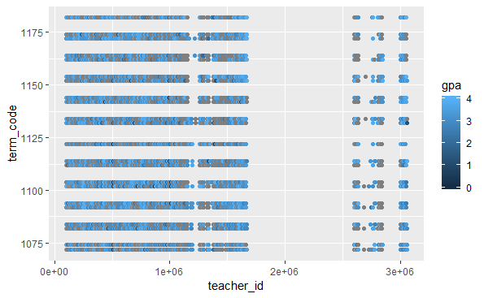

*CANNOT visually detect any pattern or trend.*

# Question E.

1. According to [UWM Busar’s Office](http://www.bussvc.wisc.edu/bursar/termcode.html), academic year 2017 has the term codes 1174, 1176, 1182
2. Extract 2017 records
3. Count frequency of teachers per course
4. [Sort data](https://www.statmethods.net/management/sorting.html)
5. [Sort function](https://stackoverflow.com/questions/19727029/how-do-i-get-a-list-sorted-by-frequency-in-r)

`r`r gpa2017 <- subset(df6, df6$term_code == c(1174,1176,1182)) summary(gpa2017)

```
 course_offering_uuid section_uuid         teacher_id
 Length:3169          Length:3169        Min.   : 103165
 Class :character     Class :character   1st Qu.:2600902
 Mode  :character     Mode  :character   Median :4218443
                                         Mean   :3700597
                                         3rd Qu.:5209029
                                         Max.   :6054989

 teacher_name       course_uuid          term_code
 Length:3169        Length:3169        Min.   :1174
 Class :character   Class :character   1st Qu.:1174
 Mode  :character   Mode  :character   Median :1174
                                       Mean   :1178
                                       3rd Qu.:1182
                                       Max.   :1182

 course_name             gpa
 Length:3169        Min.   :0.000
 Class :character   1st Qu.:3.079
 Mode  :character   Median :3.420
                    Mean   :3.378
                    3rd Qu.:3.767
                    Max.   :4.000
                    NA's   :1063
```

`r`r fav2017cnt <- count(gpa2017, vars = c(‘course_name’)) # , ‘teacher_name’ summary(fav2017cnt)

```
 course_name             freq
 Length:1455        Min.   :  1.000
 Class :character   1st Qu.:  1.000
 Mode  :character   Median :  1.000
                    Mean   :  2.178
                    3rd Qu.:  2.000
                    Max.   :182.000
```

[output not shown]

#### PIck a subject to find instructors

`r`r favs1 <- subset(gpa2017, gpa2017$course_name == ‘General Physics’) summary(favs1)

```
 course_offering_uuid section_uuid         teacher_id
 Length:32            Length:32          Min.   :2601733
 Class :character     Class :character   1st Qu.:5029672
 Mode  :character     Mode  :character   Median :5610168
                                         Mean   :5283105
                                         3rd Qu.:5703572
                                         Max.   :5910931
 teacher_name       course_uuid          term_code
 Length:32          Length:32          Min.   :1174
 Class :character   Class :character   1st Qu.:1174
 Mode  :character   Mode  :character   Median :1178
                                       Mean   :1178
                                       3rd Qu.:1182
                                       Max.   :1182
 course_name             gpa
 Length:32          Min.   :2.871
 Class :character   1st Qu.:2.941
 Mode  :character   Median :3.058
                    Mean   :3.027
                    3rd Qu.:3.064
                    Max.   :3.172
```

`r`r instrs1 <- favs1$teacher_name instrs1

```
 [1] \MARK S RZCHOWSKI\             \MATTHEW HERNDON\
 [3] \ANDREW LOVERIDGE\             \NICHOLAS BREWER\
 [5] \MANUEL SILVA\                 \DEREK GARDNER\
 [7] \DIPTARANJAN DAS\              \TAO PENG\
 [9] \GANDHARI WATTAL\              \KONSTANTINOS HORAITES\
[11] \MAXWELL GRANGER\              \DAVID GOLD\
[13] \VANESSA LOPEZ BARQUERO\       \AHMET BARIS OZGULER\
[15] \RACHEL MYERS\                 \HRUDAY MALLUBHOTLA\
[17] \GREGORY HOLDMAN\              \HARRY HAUSNER\
[19] \JOEL SIEGEL\                  \BRADLEY KUMM\
[21] \JITHIN MADHUSUDANAN SREEKALA\ \ANDREW LOELIGER\
[23] \GAGE BONNER\                  \URVASHI GUPTA\
[25] \SIDNEY VETENS\                \ZACHARY KREBS\
[27] \CHEN-HSUN CHAN\               \TREVOR OXHOLM\
[29] \ADAM ROUHIAINEN\              \. LEAH TOM\
[31] \ABHISHIKTH MALLAMPALLI\       \HE HE\
```

### Find professors ratings at [ratemyprofessor](https://www.ratemyprofessors.com/campusRatings.jsp?sid=1256)

#### Issues

1. [Professor Personal Page] contains

`html`html ShowRatings.jsp?tid=994788

```
    <div class=\left-breakdown\>
      <span class=\take-again-help-text help-text\> Percentage excludes ratings added prior to 05/25/16. </span>
      <div class=\breakdown-wrapper\>
        <div class=\breakdown-header quality-header\>
          <div class=\breakdown-container quality\>
            <div>
              Overall Quality
              <div class=\grade\ title=\\>2.0</div>
```

2. [Initial School Page] (https://www.ratemyprofessors.com/campusRatings.jsp?sid=1256) only shows a few professors.
3. Even after clicking on the Show All Professor button to see [this page] (https://www.ratemyprofessors.com/search.jsp?queryBy=schoolId&schoolName=University+of+Wisconsin+-+Madison&schoolID=1256&queryoption=TEACHER) only a limited number of the professors are returned on a dynamically generated side bar which does not show all professors still (4433 professors found)
4. But most challenging task is that the professor names in the overall rating list are shown last name first and in proper case, while the instructor name in our data consist of full (first then last) name in all all upper case.

#### Professor Matt Herndon of Physics Dept (rating: 2.0)

`r`r gpa.matt <- subset(df6, df6$teacher_name == 'MATTHEW HERNDON' & df6$course_name == ‘General Physics’) summary(gpa.matt)

```
 course_offering_uuid section_uuid         teacher_id
 Length:9             Length:9           Min.   :4003841
 Class :character     Class :character   1st Qu.:4003841
 Mode  :character     Mode  :character   Median :4003841
                                         Mean   :4003841
                                         3rd Qu.:4003841
                                         Max.   :4003841
 teacher_name       course_uuid          term_code
 Length:9           Length:9           Min.   :1074
 Class :character   Class :character   1st Qu.:1094
 Mode  :character   Mode  :character   Median :1122
                                       Mean   :1125
                                       3rd Qu.:1154
                                       Max.   :1182
 course_name             gpa
 Length:9           Min.   :2.897
 Class :character   1st Qu.:2.956
 Mode  :character   Median :2.965
                    Mean   :2.991
                    3rd Qu.:3.058
                    Max.   :3.123
```

`r`r View(gpa.matt)

*END OF FILE*